# Answer: 7 - Survival Analysis

DrPH Yr 1 Sem 1 2019/2020

14/12/2019

# Dataset

Dataset stroke_outcome.dta had these variables

- ID : unique identification number
- sex : patient’s gender (male/female)
- race : ethnicity (malay/chinese)
- doa : date of admission
- dod : date of discharge
- gcs : GCS score
- sbp : systolic BP
- dbp : diasolic BP
- age : age of patient during admission (in years)
- event : outcome of patient during date of discharge (censored/dead)
- dm2 : DM status (no/yes)
- hpt2 : Hpt status (no/yes)
- race2 : Malay Ethnicity (no/yes)

As a researcher, you interested to find factors associated with survival of stroke patient.

```r
library(pacman)
p_load(haven, foreign, broom, tidyverse, psych, knitr, lubridate, survival, survminer)
mydata <- read_dta("stroke_outcome.dta")
mydata <- mydata %>%
  mutate_if(is.labelled, ~as_factor(.))
mydata <- mydata %>%
  mutate(dur = mydata$doa %--% mydata$dod) %>%
  mutate(dur = as.duration(dur)) %>%
  mutate(dur_days = dur/ddays(1))
mydata
```

```
## # A tibble: 262 x 16
##    id    sex   race  doa        dod          gcs   sbp   dbp   age event
##    <chr> <fct> <fct> <date>     <date>     <dbl> <dbl> <dbl> <dbl> <fct>
##  1 B040~ fema~ malay 2012-05-23 2012-05-29    14   108    99    80 cens~
##  2 A076~ fema~ malay 2011-10-05 2011-10-10    11   126    70    74 cens~
##  3 A170~ male  othe~ 2011-02-07 2011-02-25    12   167    71    73 cens~
##  4 B459~ male  malay 2011-03-06 2011-03-29    13   172   100    54 cens~
##  5 B494~ male  malay 2012-06-08 2012-06-11    15   160    88    70 cens~
##  6 B481~ fema~ malay 2011-12-23 2012-01-12     8   173    95    66 cens~
##  7 A071~ male  malay 2011-04-17 2011-04-21    15   120    82    25 cens~
##  8 A081~ male  malay 2012-02-04 2012-02-06    15   143    76    56 cens~
##  9 B480~ fema~ malay 2011-12-19 2012-01-01    11   169    92    55 cens~
## 10 B283~ male  malay 2011-11-15 2011-11-21    11   173   123    29 cens~
## # ... with 252 more rows, and 6 more variables: dm2 <fct>, hpt2 <fct>,
## #   race2 <fct>, event_s <dbl>, dur <Duration>, dur_days <dbl>
```

# Question 1

Explain the KM Estimation for the survival of the stroke patient

## Answer

The median survival time for the stroke patient was 22 days (95% CI = 12, NA)

```r
KM_Overall <- survfit(Surv(time = dur_days, event == "dead")~ 1,
                     data = mydata, type = "kaplan-meier")
KM_Overall
```

```
## Call: survfit(formula = Surv(time = dur_days, event == "dead") ~ 1,
##     data = mydata, type = "kaplan-meier")
##
##       n  events  median 0.95LCL 0.95UCL
##     262      63      22      12      NA
```

KM Plot Shown below

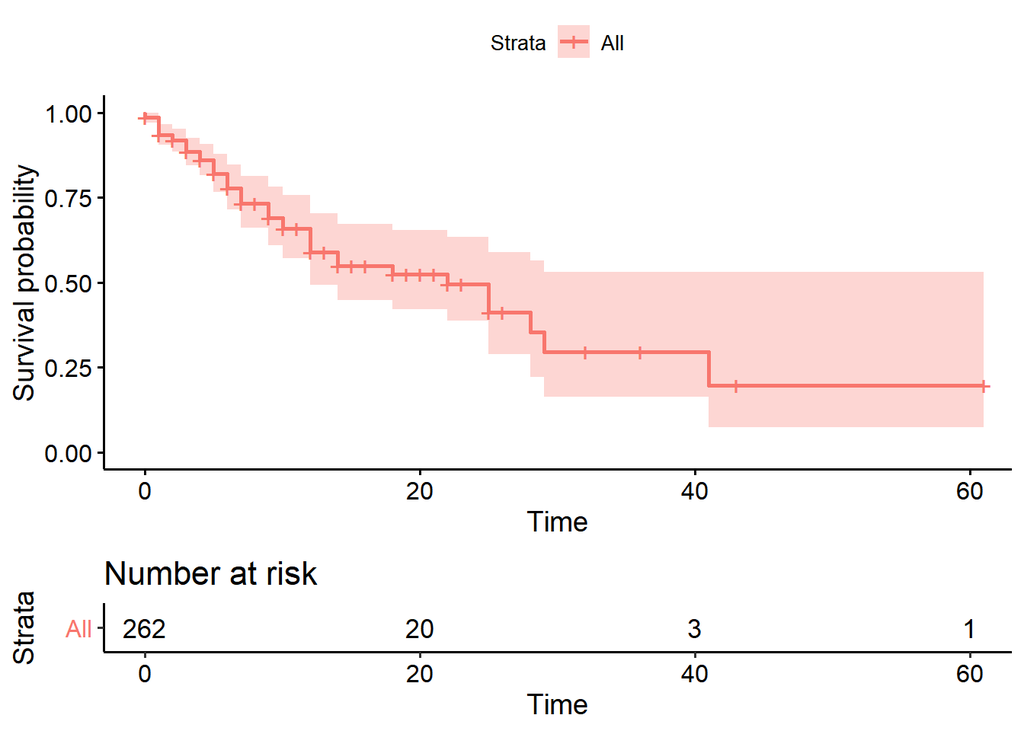

```r
ggsurvplot(KM_Overall, data = mydata, risk.table = T)
```

# Question 2

Explain the KM Estimation for the survival of the stroke patient, by DM status (variable:dm2)

## Answer

The median survival time for non DM patient was 29 days (95% CI = 25, NA), while the median survival time for DM patient was 12 days (95% CI = 9, 22). There was significant different of survival time between DM patient and non DM patient (p < 0.001)

```r
KM_DM <- survfit(Surv(time = dur_days, event == "dead")~ dm2,
                 data = mydata, type = "kaplan-meier")
KM_DM
```

```
## Call: survfit(formula = Surv(time = dur_days, event == "dead") ~ dm2,
##     data = mydata, type = "kaplan-meier")
##
##           n events median 0.95LCL 0.95UCL
## dm2=no  161     24     29      25      NA
## dm2=yes 101     39     12       9      22
```

The KM plot was shown below

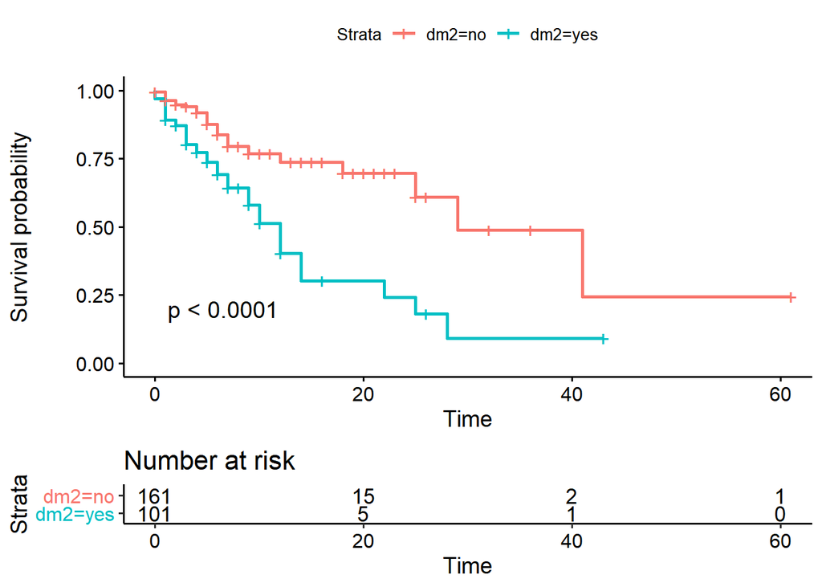

```r
ggsurvplot(KM_DM, data = mydata, risk.table = T, pval = T)
```

# Question 3

Analyse the relationship between variable “event” and these covariate, “sex”, “gcs”, “sbp” and “age”, by using cox regression. name the model as “mod.metab”.

Write the estimated regression parameter in a table based on “mod.metab”

Interpret the parameter

## Answer

```r
mod.metab <- coxph(Surv(time = dur_days, event == "dead")~ sex + gcs + sbp + age,
                   data = mydata)
summary(mod.metab)
```

```
## Call:
## coxph(formula = Surv(time = dur_days, event == "dead") ~ sex +
##     gcs + sbp + age, data = mydata)
##
##   n= 262, number of events= 63
##
##                coef exp(coef)  se(coef)      z Pr(>|z|)
## sexfemale  0.049475  1.050720  0.274347  0.180   0.8569
## gcs       -0.232075  0.792887  0.033611 -6.905 5.03e-12 ***
## sbp        0.001721  1.001722  0.003745  0.459   0.6459
## age        0.017897  1.018058  0.010193  1.756   0.0791 .
## ---
## Signif. codes:  0 '***' 0.001 '**' 0.01 '*' 0.05 '.' 0.1 ' ' 1
##
##           exp(coef) exp(-coef) lower .95 upper .95
## sexfemale    1.0507     0.9517    0.6137    1.7989
## gcs          0.7929     1.2612    0.7423    0.8469
## sbp          1.0017     0.9983    0.9944    1.0091
## age          1.0181     0.9823    0.9979    1.0386
##
## Concordance= 0.825  (se = 0.026 )
## Likelihood ratio test= 58.3  on 4 df,   p=7e-12
## Wald test            = 54.76  on 4 df,   p=4e-11
## Score (logrank) test = 66.89  on 4 df,   p=1e-13
```

Estimated regression in table

```r
tidy(mod.metab)
```

```
## # A tibble: 4 x 7
##   term      estimate std.error statistic  p.value conf.low conf.high
##   <chr>        <dbl>     <dbl>     <dbl>    <dbl>    <dbl>     <dbl>
## 1 sexfemale  0.0495    0.274       0.180 8.57e- 1 -0.488     0.587
## 2 gcs       -0.232     0.0336     -6.90  5.03e-12 -0.298    -0.166
## 3 sbp        0.00172   0.00375     0.459 6.46e- 1 -0.00562   0.00906
## 4 age        0.0179    0.0102      1.76  7.91e- 2 -0.00208   0.0379
```

# Question 4

Add an interaction term between variable “sex” and “gcs” to the model “mod.metab”. Run the analysis and name the model as “mod.metab.int”

Write the estimated regression parameters in a table based on “mod.metab.int”

## Answer

```r
mod.metab.int <- coxph(Surv(time = dur_days, event == "dead")~ sex + gcs + sbp + age + sex:gcs,
                       data = mydata)
summary(mod.metab.int)
```

```
## Call:
## coxph(formula = Surv(time = dur_days, event == "dead") ~ sex +
##     gcs + sbp + age + sex:gcs, data = mydata)
##
##   n= 262, number of events= 63
##
##                    coef exp(coef)  se(coef)      z Pr(>|z|)
## sexfemale     -0.561752  0.570209  0.564310 -0.995   0.3195
## gcs           -0.279845  0.755901  0.053126 -5.268 1.38e-07 ***
## sbp            0.002005  1.002007  0.003779  0.531   0.5957
## age            0.018643  1.018818  0.010228  1.823   0.0683 .
## sexfemale:gcs  0.079609  1.082864  0.065846  1.209   0.2267
## ---
## Signif. codes:  0 '***' 0.001 '**' 0.01 '*' 0.05 '.' 0.1 ' ' 1
##
##               exp(coef) exp(-coef) lower .95 upper .95
## sexfemale        0.5702     1.7537    0.1887    1.7234
## gcs              0.7559     1.3229    0.6812    0.8389
## sbp              1.0020     0.9980    0.9946    1.0095
## age              1.0188     0.9815    0.9986    1.0394
## sexfemale:gcs    1.0829     0.9235    0.9518    1.2320
##
## Concordance= 0.827  (se = 0.025 )
## Likelihood ratio test= 59.79  on 5 df,   p=1e-11
## Wald test            = 55.5  on 5 df,   p=1e-10
## Score (logrank) test = 68.9  on 5 df,   p=2e-13
```

Estimated regression in table

```r
tidy(mod.metab.int)
```

```
## # A tibble: 5 x 7
##   term          estimate std.error statistic     p.value conf.low conf.high
##   <chr>            <dbl>     <dbl>     <dbl>       <dbl>    <dbl>     <dbl>
## 1 sexfemale     -0.562     0.564      -0.995 0.320       -1.67      0.544
## 2 gcs           -0.280     0.0531     -5.27  0.000000138 -0.384    -0.176
## 3 sbp            0.00200   0.00378     0.531 0.596       -0.00540   0.00941
## 4 age            0.0186    0.0102      1.82  0.0683      -0.00140   0.0387
## 5 sexfemale:gcs  0.0796    0.0658      1.21  0.227       -0.0494    0.209
```

# Question 5

Compare model “mod.metab.int” and “mod.metab” using an approprite test and interpret the result

## Answer

the model was compared using chi-square test.

```r
anova(mod.metab.int, mod.metab, test = "Chisq")
```

```
## Analysis of Deviance Table
##  Cox model: response is  Surv(time = dur_days, event == "dead")
##  Model 1: ~ sex + gcs + sbp + age + sex:gcs
##  Model 2: ~ sex + gcs + sbp + age
##    loglik Chisq Df P(>|Chi|)
## 1 -255.88
## 2 -256.62 1.487  1    0.2227
```

no significant different between model “mod.metab.int” and “mod.metab” (p = 0.223). hence there was no significant interaction between “sex” and “gcs”

# Question 6

Predict probability survival at 14 days when sex = female, gcs = 10, sbp = 110 and age = 75, based on “mod.metab” and “mod.metab.int”, as compared to the population average.

## Answer - option 1

Predicted hazard = $h_0(t) \times exp^{(\beta X)}$.

Predicted hazard = base hazard X linear predictor

For **mod.metab model**

base hazard at 14 days was 0.311109196

```r
basehaz(mod.metab)
```

```
##         hazard time
## 1  0.009355759    0
## 2  0.043225765    1
## 3  0.055616175    2
## 4  0.080856902    3
## 5  0.097847949    4
## 6  0.124238248    5
## 7  0.149983807    6
## 8  0.178976484    7
## 9  0.178976484    8
## 10 0.208351500    9
## 11 0.230806313   10
## 12 0.230806313   11
## 13 0.281158123   12
## 14 0.281158123   13
```

[output cut: 18 more lines]

linear predictor

```r
new_data <- expand.grid(sex = c("female"),
                        gcs = c(10),
                        sbp = c(110),
                        age = c(75))
lp.pred <- predict(mod.metab, newdata = new_data, type = "lp")
0.311109196*exp(lp.pred)
```

```
##         1
## 0.5977524
```

For **mod.metab.int model**

base hazard at 14 days was 0.295888040

```r
basehaz(mod.metab.int)
```

```
##         hazard time
## 1  0.009004446    0
## 2  0.041533597    1
## 3  0.053519801    2
## 4  0.077851725    3
## 5  0.094233399    4
## 6  0.119441939    5
## 7  0.144113737    6
## 8  0.171761294    7
## 9  0.171761294    8
## 10 0.199306772    9
## 11 0.220591633   10
## 12 0.220591633   11
## 13 0.267772183   12
## 14 0.267772183   13
```

[output cut: 18 more lines]

linear predictor

```r
new_data_int <- expand.grid(sex = c("female"),
                            gcs = c(10),
                            sbp = c(110),
                            age = c(75))
lp.pred_int <- predict(mod.metab.int, newdata = new_data_int, type = "lp")
0.295888040*exp(lp.pred_int)
```

```
##         1
## 0.6296699
```

## Answer - option 2

For **mod.tab**

```r
new_data2 <- expand.grid(sex = c("female"),
                         gcs = c(10),
                         sbp = c(110),
                         age = c(75),
                         dur_days = c(14),
                         event = c("dead"))
pred.exp2 <- predict(mod.metab, newdata = new_data2, type = "expected")
cbind(new_data2, pred.exp2)
```

```
##      sex gcs sbp age dur_days event pred.exp2
## 1 female  10 110  75       14  dead 0.5977524
```

For **mod.tab.int**

```r
new_data2_int <- expand.grid(sex = c("female"),
                             gcs = c(10),
                             sbp = c(110),
                             age = c(75),
                             dur_days = c(14),
                             event = c("dead"))
pred.exp2_int <- predict(mod.metab.int, newdata = new_data2_int, type = "expected")
cbind(new_data2_int, pred.exp2_int)
```

```
##      sex gcs sbp age dur_days event pred.exp2_int
## 1 female  10 110  75       14  dead     0.6296699
```